# Predicting Prolonged ICU Stay in Sepsis Patients

UCLA MDSH Biostat 203B/212A Final Project; March 2026: team members: Yasmine Tani, Charlotte Lee , Brandon Brushwyler

Author

Yasmine Tani

```r
options(readr.show_col_types = FALSE)
```

**II. ABSTRACT**

Sepsis is a critical healthcare challenge characterized by organ dysfunction. Early prediction using high-dimensional Intensive Care Unit (ICU) data can significantly improve clinical outcomes. Every hour of delayed treatment significantly increases mortality, and there are various factors coming in to play for outcomes of sepsis patients. Thus, there is an immediate need for automated tools that can filter through the noise to provide early, actionable risk scores.

Our primary goal was to develop an end-to-end reproducible machine learning (ML) pipeline that predicts prolonged ICU stays (>14 days as defined in this study) within a 24-hour window. We investigate whether a streamlined 19-feature pipeline could accurately predict whether or not a patient would experience a prolonged stay in the ICU due to their primary sepsis diagnosis.

Data for 19 clinical features was extracted from MIMIC-IV v3.1 (Johnson 2023) via Google BigQuery through R Studio, and 3 key models were evaluated: Lasso Regression, Random Forest, and XGBoost. An interactive Shiny dashboard was deployed for results visualization.

Our analysis revealed that the Lasso Regression model provided the most robust performance, achieving an AUROC of 0.78. This outperformed the more complex XGBoost (0.76) and Random Forest (0.75) models. Feature importance analysis showed that the model relied heavily on physiological acute status—specifically elevated lactate levels, high respiratory rates, and the requirement for vasopressors—rather than socio-economic demographics. This suggests that the signal for sepsis mortality is strongly linear and concentrated in markers of metabolic and hemodynamic failure. These results imply that focusing on a high-fidelity core of 19 physiological features can provide reliable risk stratification that clinicians can actually trust.

**III. INTRODUCTION**

*(a) Background*

Sepsis is a life-threatening condition characterized by a dysregulated host response to infection, leading to organ dysfunction. Within the ICU, sepsis remains a primary driver of mortality as well as healthcare costs.

It is therefore imperative for clinicians and ICU/hospital staff to become aware – very early on– of the predicted length of stay per patient and what main factors are the driver of this. With such models in one’s toolbox, proper treatment to reduce the length of stay and severity of sepsis outcomes can be administered earlier on.

*(b) Literature Review*

There were various pieces of literature that informed our decisions and provided context into our modeling and our work. Most relevant was work by **Huang et al. (2025)**, ‘*MIMIC-Sepsis: A Curated Benchmark for Modeling and Learning from Sepsis Trajectories in the ICU*.’ This paper looked into various outcomes of sepsis in the ICU (mortality, prolonged stay, readmission, septic shock, etc.) and utilized various models and features for these predictions (Huang 2025). Similarly,we utilized a 24-hour period to define our clinical observations for the model, added prescription medication though we actually excluded antibiotics as a confounding variable, and we extracted very similar labs and vitals such as bilirubin and platelets.

Furthermore, our feature selection was informed by the work of **Xu et al. (2024)**, ‘*Early versus delayed enteral nutrition in ICU patients with sepsis: a propensity score-matched analysis based on the MIMIC-IV database*.’ Xu et al. demonstrates that enteral nutrition impacts the length of ICU stay (Xu 2024), which we excluded as a predictor due to causal inference. This would push the model to believe that a patient being fed leads to them doing better which confuses a clinician’s decisions with the patient’s sickness and physiological predictors.

Additionally, the architectural philosophy of our project was informed by the *DSC 180AB Sepsis Capstone framework*by Professor Kyle Shannon, which advocates for the creation of ‘real-world reporting aspects’ rather than isolated models (Shannon 2024). Following their emphasis on the ‘patient journey,’ we developed our Patient Trajectory tab in our ShinyAppy to visualize the intricate ICU cases described in their syllabus. This ensures our deliverable serves as a bridge between data science and clinical decision-making, fulfilling the ‘impact-focused’ goals of modern healthcare informatics.

*(c) Problem Statement*

Despite the wealth of data available in Electronic Health Records (EHR) like MIMIC-IV, clinicians in high-pressure ICU environments face a “signal-to-noise” crisis. Current clinical protocols often rely on manual scoring systems (such as SOFA or SIRS) that are reactive rather than proactive, or they depend on “black-box” machine learning models that offer high accuracy but zero transparency.

*(d) Objectives*

The specific objectives of this project were:

1. Data Cleaning: Designing a strong cohort to represent our Sepsis ICU adult population from the MIMIC-IV data
2. Predictive Modeling & Predictor Selection: Developing a binary classification of models to identify prolonged vs short stays, filtering to relevant predictors, and asessing with models of various complexity
3. Clinical Utility: Provide a “Patient Interrogator” to help clinicians see why a patient might be trending toward a long stay through trajectory visualization.

*(e) Project Aims/Hypotheses*

**Aim 1:** To achieve an AUROC > 0.70 in distinguishing between “standard” stays and “prolonged” (>14 day) stays.

**Aim 2:** To identify if chronic comorbidities (like CKD or Diabetes) or acute physiological markers (like Lactate) are the primary drivers of long-term ICU dependency.

**Hypothesis:** We hypothesize that patients with chronic comorbidites, especially cardiac conditions, as well as patients with elevated lactate levels in their first 24 hours will require an extended ICU stay.

**IV. METHODS**

4.1 Data Source, Ethics, and Materials

The data for this project was sourced from **MIMIC-IV v3.1**, a large-scale, de-identified EHR database. Access was granted following the completion of the **CITI Program “Data or Specimens Replacement”** training adhering strictly to the PhysioNet Data Use Agreement. To ensure patient privacy, no Protected Health Information (PHI) was downloaded to local storage; instead, we utilized a secure cloud-to-local pipeline.

Given the volume of certain datasets, we used BigQuery and various ingestion tools to produce our final cohort, and ensured to not collect() too early out of risk of forcing unnecessary computational power. We loaded various necessary packages for acquiring summaries of our data, producing tibbles, assessing through various modeling, and more. Additionally, we spent substantial time looking inside our data to understand it better.

```r
#loading libraries we may need

library(arrow)
library(gtsummary)
library(memuse)
library(pryr)
library(R.utils)
library(tidyverse)
library(stringr)
library(ggplot2)
library(lubridate)
library(readr)
library(randomForest)
library(data.table)
library(glmnet)
```

```bash
# we are using icu data so let us again see contents of mimic icu
ls -l ~/mimic/icu
```

```
total 8506784
-rw-r--r--@ 1 yasminetani  staff       41566 Apr 13  2024 caregiver.csv.gz
-rw-r--r--@ 1 yasminetani  staff  3502392765 Apr 13  2024 chartevents.csv.gz
-rw-r--r--@ 1 yasminetani  staff       58741 Apr 13  2024 d_items.csv.gz
-rw-r--r--@ 1 yasminetani  staff    63481196 Apr 13  2024 datetimeevents.csv.gz
-rw-r--r--@ 1 yasminetani  staff     3342355 Oct  3  2024 icustays.csv.gz
-rw-r--r--@ 1 yasminetani  staff   311642048 Apr 13  2024 ingredientevents.csv.gz
-rw-r--r--@ 1 yasminetani  staff   401088206 Apr 13  2024 inputevents.csv.gz
-rw-r--r--@ 1 yasminetani  staff    49307639 Apr 13  2024 outputevents.csv.gz
-rw-r--r--@ 1 yasminetani  staff    24096834 Apr 13  2024 procedureevents.csv.gz
```

```bash
# we will also need labs and more from the hopsital data so lets see whats in that folder
# folder and then the head of the admissions csv
ls -l ~/mimic/hosp
```

```
total 12306248
-rw-r--r--@ 1 yasminetani  staff    19928140 Jun 24  2024 admissions.csv.gz
-rw-r--r--@ 1 yasminetani  staff      427554 Apr 12  2024 d_hcpcs.csv.gz
-rw-r--r--@ 1 yasminetani  staff      876360 Apr 12  2024 d_icd_diagnoses.csv.gz
-rw-r--r--@ 1 yasminetani  staff      589186 Apr 12  2024 d_icd_procedures.csv.gz
-rw-r--r--@ 1 yasminetani  staff       13169 Oct  3  2024 d_labitems.csv.gz
-rw-r--r--@ 1 yasminetani  staff    33564802 Oct  3  2024 diagnoses_icd.csv.gz
-rw-r--r--@ 1 yasminetani  staff     9743908 Oct  3  2024 drgcodes.csv.gz
-rw-r--r--@ 1 yasminetani  staff   748158322 Apr 13  2024 emar_detail.csv.gz
-rw-r--r--@ 1 yasminetani  staff   811305629 Apr 12  2024 emar.csv.gz
-rw-r--r--@ 1 yasminetani  staff     2162335 Apr 12  2024 hcpcsevents.csv.gz
-rw-r--r--@ 1 yasminetani  staff  2592909134 Oct  3  2024 labevents.csv.gz
-rw-r--r--@ 1 yasminetani  staff   117644075 Oct  3  2024 microbiologyevents.csv.gz
-rw-r--r--@ 1 yasminetani  staff    44069351 Oct  3  2024 omr.csv.gz
-rw-r--r--@ 1 yasminetani  staff     2835586 Apr 12  2024 patients.csv.gz
-rw-r--r--@ 1 yasminetani  staff   525708076 Apr 12  2024 pharmacy.csv.gz
-rw-r--r--@ 1 yasminetani  staff    55267894 Apr 12  2024 poe_detail.csv.gz
-rw-r--r--@ 1 yasminetani  staff   666594177 Apr 12  2024 poe.csv.gz
-rw-r--r--@ 1 yasminetani  staff   606298611 Apr 12  2024 prescriptions.csv.gz
-rw-r--r--@ 1 yasminetani  staff     7777324 Apr 12  2024 procedures_icd.csv.gz
-rw-r--r--@ 1 yasminetani  staff      127330 Apr 12  2024 provider.csv.gz
-rw-r--r--@ 1 yasminetani  staff     8569241 Apr 12  2024 services.csv.gz
-rw-r--r--@ 1 yasminetani  staff    46185771 Oct  3  2024 transfers.csv.gz
```

```bash
gzcat ~/mimic/hosp/admissions.csv.gz | head
```

```
subject_id,hadm_id,admittime,dischtime,deathtime,admission_type,admit_provider_id,admission_location,discharge_location,insurance,language,marital_status,race,edregtime,edouttime,hospital_expire_flag
10000032,22595853,2180-05-06 22:23:00,2180-05-07 17:15:00,,URGENT,P49AFC,TRANSFER FROM HOSPITAL,HOME,Medicaid,English,WIDOWED,WHITE,2180-05-06 19:17:00,2180-05-06 23:30:00,0
10000032,22841357,2180-06-26 18:27:00,2180-06-27 18:49:00,,EW EMER.,P784FA,EMERGENCY ROOM,HOME,Medicaid,English,WIDOWED,WHITE,2180-06-26 15:54:00,2180-06-26 21:31:00,0
10000032,25742920,2180-08-05 23:44:00,2180-08-07 17:50:00,,EW EMER.,P19UTS,EMERGENCY ROOM,HOSPICE,Medicaid,English,WIDOWED,WHITE,2180-08-05 20:58:00,2180-08-06 01:44:00,0
10000032,29079034,2180-07-23 12:35:00,2180-07-25 17:55:00,,EW EMER.,P06OTX,EMERGENCY ROOM,HOME,Medicaid,English,WIDOWED,WHITE,2180-07-23 05:54:00,2180-07-23 14:00:00,0
10000068,25022803,2160-03-03 23:16:00,2160-03-04 06:26:00,,EU OBSERVATION,P39NWO,EMERGENCY ROOM,,,English,SINGLE,WHITE,2160-03-03 21:55:00,2160-03-04 06:26:00,0
10000084,23052089,2160-11-21 01:56:00,2160-11-25 14:52:00,,EW EMER.,P42H7G,WALK-IN/SELF REFERRAL,HOME HEALTH CARE,Medicare,English,MARRIED,WHITE,2160-11-20 20:36:00,2160-11-21 03:20:00,0
10000084,29888819,2160-12-28 05:11:00,2160-12-28 16:07:00,,EU OBSERVATION,P35NE4,PHYSICIAN REFERRAL,,Medicare,English,MARRIED,WHITE,2160-12-27 18:32:00,2160-12-28 16:07:00,0
10000108,27250926,2163-09-27 23:17:00,2163-09-28 09:04:00,,EU OBSERVATION,P40JML,EMERGENCY ROOM,,,English,SINGLE,WHITE,2163-09-27 16:18:00,2163-09-28 09:04:00,0
10000117,22927623,2181-11-15 02:05:00,2181-11-15 14:52:00,,EU OBSERVATION,P47EY8,EMERGENCY ROOM,,Medicaid,English,DIVORCED,WHITE,2181-11-14 21:51:00,2181-11-15 09:57:00,0
```

```bash
# before i ingest the icu csv i want to look into all these csv's to make sure i know
# where to get the data from and what the variables would look like, etc.
#check column names for admissions.csv.gz [ first few lines]
gzcat ~/mimic/hosp/admissions.csv.gz | head
```

```
subject_id,hadm_id,admittime,dischtime,deathtime,admission_type,admit_provider_id,admission_location,discharge_location,insurance,language,marital_status,race,edregtime,edouttime,hospital_expire_flag
10000032,22595853,2180-05-06 22:23:00,2180-05-07 17:15:00,,URGENT,P49AFC,TRANSFER FROM HOSPITAL,HOME,Medicaid,English,WIDOWED,WHITE,2180-05-06 19:17:00,2180-05-06 23:30:00,0
10000032,22841357,2180-06-26 18:27:00,2180-06-27 18:49:00,,EW EMER.,P784FA,EMERGENCY ROOM,HOME,Medicaid,English,WIDOWED,WHITE,2180-06-26 15:54:00,2180-06-26 21:31:00,0
10000032,25742920,2180-08-05 23:44:00,2180-08-07 17:50:00,,EW EMER.,P19UTS,EMERGENCY ROOM,HOSPICE,Medicaid,English,WIDOWED,WHITE,2180-08-05 20:58:00,2180-08-06 01:44:00,0
10000032,29079034,2180-07-23 12:35:00,2180-07-25 17:55:00,,EW EMER.,P06OTX,EMERGENCY ROOM,HOME,Medicaid,English,WIDOWED,WHITE,2180-07-23 05:54:00,2180-07-23 14:00:00,0
10000068,25022803,2160-03-03 23:16:00,2160-03-04 06:26:00,,EU OBSERVATION,P39NWO,EMERGENCY ROOM,,,English,SINGLE,WHITE,2160-03-03 21:55:00,2160-03-04 06:26:00,0
10000084,23052089,2160-11-21 01:56:00,2160-11-25 14:52:00,,EW EMER.,P42H7G,WALK-IN/SELF REFERRAL,HOME HEALTH CARE,Medicare,English,MARRIED,WHITE,2160-11-20 20:36:00,2160-11-21 03:20:00,0
10000084,29888819,2160-12-28 05:11:00,2160-12-28 16:07:00,,EU OBSERVATION,P35NE4,PHYSICIAN REFERRAL,,Medicare,English,MARRIED,WHITE,2160-12-27 18:32:00,2160-12-28 16:07:00,0
10000108,27250926,2163-09-27 23:17:00,2163-09-28 09:04:00,,EU OBSERVATION,P40JML,EMERGENCY ROOM,,,English,SINGLE,WHITE,2163-09-27 16:18:00,2163-09-28 09:04:00,0
10000117,22927623,2181-11-15 02:05:00,2181-11-15 14:52:00,,EU OBSERVATION,P47EY8,EMERGENCY ROOM,,Medicaid,English,DIVORCED,WHITE,2181-11-14 21:51:00,2181-11-15 09:57:00,0
```

```bash
#how many unique patients?
gzcat ~/mimic/hosp/admissions.csv.gz | tail -n +2 | awk -F, '{print $1}' | sort | uniq | wc -l
```

```
  223452
```

```bash
#for our icu data
#count ICU stays [rows of this]
echo "--- ICU STAYS ---"
gzcat ~/mimic/icu/icustays.csv.gz | tail -n +2 | wc -l

#count unique patients w/ subject_id
echo "--- UNIQUE PATIENTS ---"
gzcat ~/mimic/icu/icustays.csv.gz | tail -n +2 | awk -F, '{print $1}' | sort | uniq | wc -l
```

```
--- ICU STAYS ---
   94458
--- UNIQUE PATIENTS ---
   65366
```

```r
# load the hospital data (where patients and diagnoses live)
patients <- read_csv("mimic/hosp/patients.csv.gz")
admissions <- read_csv("mimic/hosp/admissions.csv.gz")
diagnoses_icd <- read_csv("mimic/hosp/diagnoses_icd.csv.gz")

# load the ICU data (where the stays live)
icu_stays <- read_csv("mimic/icu/icustays.csv.gz")
```

```r
library(dplyr)
library(readr)

# load tables
admissions <- read_csv("mimic/hosp/admissions.csv.gz")
icu_stays <- read_csv("mimic/icu/icustays.csv.gz")

# join them together
# use inner_join to keep only those who appear in both tables
icu_admissions <- admissions %>%
  inner_join(icu_stays, by = c("subject_id", "hadm_id"))

# counts
total_admissions <- n_distinct(admissions$hadm_id)
total_icu_admissions <- n_distinct(icu_admissions$hadm_id)
total_icu_stays <- n_distinct(icu_admissions$stay_id)

print(paste("Total Hospital Admissions:", total_admissions))
```

```
[1] "Total Hospital Admissions: 546028"
```

```r
print(paste("Total Admissions that included an ICU stay:", total_icu_admissions))
```

```
[1] "Total Admissions that included an ICU stay: 85242"
```

```r
print(paste("Total individual ICU stays (stay_id):", total_icu_stays))
```

```
[1] "Total individual ICU stays (stay_id): 94458"
```

Inclusion & Exclusion Criteria

To ensure a clinically meaningful and homogeneous study population, we applied the following filters:

```r
# load the dictionary table
d_icd <- read_csv("mimic/hosp/d_icd_diagnoses.csv.gz")

# identify every code that has sepsis in title
sepsis_keyword_codes <- d_icd %>%
  filter(str_detect(tolower(long_title), "sepsis")) %>%
  pull(icd_code)

# filter for primary diagnosis
primary_sepsis_admissions <- diagnoses_icd %>%
  filter(seq_num == 1, icd_code %in% sepsis_keyword_codes) %>%
  select(hadm_id) %>%
  distinct()

# count
print(paste("Primary Sepsis Patients Admitted:", nrow(primary_sepsis_admissions)))
```

```
[1] "Primary Sepsis Patients Admitted: 9059"
```

```r
# initial join (sepsis in ICU)
sepsis_icu_only <- icu_stays %>% inner_join(primary_sepsis_admissions, by = "hadm_id")
print(paste("Sepsis in ICU Count:", nrow(sepsis_icu_only))) # This is the one line you wanted
```

```
[1] "Sepsis in ICU Count: 5894"
```

```r
# refine to adults and first stays
sepsis_cohort_initial <- sepsis_icu_only %>%
  inner_join(patients, by = "subject_id") %>%
  inner_join(admissions %>% select(hadm_id, race, insurance, hospital_expire_flag), by = "hadm_id") %>%
  filter(!is.na(intime), !is.na(outtime)) %>%
  mutate(age_at_admit = anchor_age + (year(intime) - anchor_year)) %>%
  filter(age_at_admit >= 18, los > 0) %>%
  group_by(subject_id) %>%
  arrange(intime) %>%
  slice(1) %>%
  ungroup()

print(paste("Adults / 1st Stay Count:", nrow(sepsis_cohort_initial)))
```

```
[1] "Adults / 1st Stay Count: 4530"
```

```r
# apply the 48-hour survival filter
sepsis_cohort_final <- sepsis_cohort_initial %>%
  filter(!(hospital_expire_flag == 1 & los < 2))

print(paste("Final Cohort Count (Survival >48h):", nrow(sepsis_cohort_final)))
```

```
[1] "Final Cohort Count (Survival >48h): 4077"
```

```r
# update data frame for the plot to include all 4 steps
cleaning_steps <- data.frame(
  Step = c("Hospital Sepsis", "ICU Sepsis", "Adults / 1st Stay", "Survival >48h"),
  Count = c(nrow(primary_sepsis_admissions), nrow(sepsis_icu_only), nrow(sepsis_cohort_initial), nrow(sepsis_cohort_final))
)
```

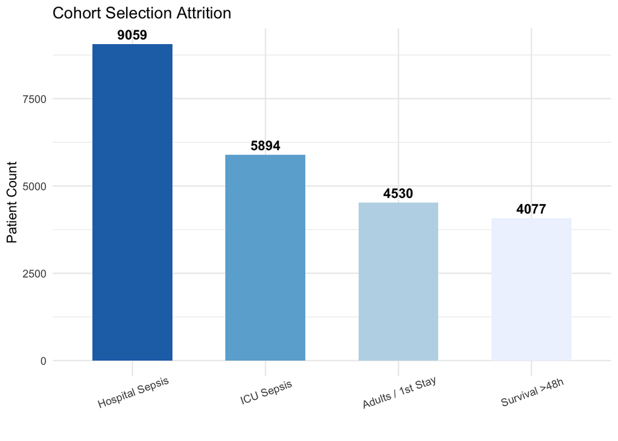

```r
#fix the order so it doesn't alphabetize
cleaning_steps$Step <- factor(cleaning_steps$Step, levels = cleaning_steps$Step)

ggplot(cleaning_steps, aes(x = Step, y = Count, fill = Step)) +
  geom_bar(stat = "identity", show.legend = FALSE, width = 0.6) +
  geom_text(aes(label = Count), vjust = -0.5, fontface = "bold") +
  theme_minimal() +
  scale_fill_brewer(palette = "Blues", direction = -1) +
  labs(
    title = "Cohort Selection Attrition",
    x = "",
    y = "Patient Count"
  ) +
  theme(axis.text.x = element_text(angle = 20, vjust = 0.8))
```

```r
# calculate average length of stay (ICU)
avg_los <- mean(sepsis_cohort_final$los, na.rm = TRUE)
med_los <- median(sepsis_cohort_final$los, na.rm = TRUE)

# create the 14-day binary target: OUR OUTCOME
sepsis_cohort_final <- sepsis_cohort_final %>%
  mutate(prolonged_stay_14 = if_else(los > 14, 1, 0))

#balance of our labels
table(sepsis_cohort_final$prolonged_stay_14)
```

```
   0    1
3724  353
```

4.2 Variables, Features, and Data Privacy

We engineered 19 features from the first 24 hours of admission. This “Index Window” is a critical ethical choice: using data from Day 3 to predict a 14-day stay would constitute data leakage. By stopping the data collection at Hour 24, we ensure the model is a true “early-warning” system.

Our features are:

**Demographics (4 Features)**

These establish the baseline profile of the patient.

- **Age:** Essential for calculating physiological reserve.
- **Gender:** Biological variance in sepsis response.
- **Race/Ethnicity:** Included to monitor for algorithmic fairness and potential healthcare disparities.
- **Insurance Type:** Used as a proxy for socio-economic status, which can impact long-term recovery and discharge planning.

**Vital Signs (5 Features)**

- **Heart Rate (HR):** Tachycardia is a primary indicator of systemic stress.
- **Mean Blood Pressure (MBP):** Critical for identifying hypotensive states.
- **Systolic Blood Pressure (SBP):** Further defines the patient’s cardiovascular stability.
- **Respiratory Rate (RR):** Often the earliest sign of clinical deterioration in sepsis.
- **Temperature:** Captures the febrile or hypothermic response to infection.

**Laboratory Results (5 Features)**

These capture the internal organ dysfunction and metabolic stress characteristic of Sepsis-3.

- **Max Lactate:** The strongest predictor of metabolic acidosis and tissue hypoperfusion.
- **Max Creatinine:** Indicates acute kidney injury (AKI).
- **Max Bilirubin:** A marker for liver dysfunction.
- **Max White Blood Cell (WBC) Count:** Indicates the severity of the immune/inflammatory response.
- **Min Platelets:** Low counts (thrombocytopenia) are a hallmark of sepsis-induced coagulopathy.

**Comorbidities & Interventions (5 Features)**

These represent the “pre-existing burden” and the intensity of treatment required.

- **Vasopressor Use:** A binary flag (Yes/No) if the patient required chemical blood pressure support in the first 24 hours. This is a massive “red flag” for a >14-day stay.
- **Hypertension:** Pre-existing cardiovascular strain.
- **Diabetes:** Impact on immune response and wound healing.
- **Chronic Kidney Disease (CKD):** High correlation with prolonged recovery times.
- **Cardiovascular Disease (CVD):** Baseline heart health significantly impacts ICU duration.

```r
# join with admissions
sepsis_cohort_final <- sepsis_cohort_final %>%
  mutate(
    # categroize race to reduce noise & maxmiize data use
    race_group = case_when(
      str_detect(race, "WHITE") ~ "WHITE",
      str_detect(race, "BLACK") ~ "BLACK",
      str_detect(race, "HISPANIC") ~ "HISPANIC",
      str_detect(race, "ASIAN") ~ "ASIAN",
      TRUE ~ "OTHER/UNKNOWN"
    ),
    # ensure Insurance is a factor
    insurance = as.factor(insurance)
  )

# breakdown of these features
print("Insurance Breakdown:")
```

```
[1] "Insurance Breakdown:"
```

```r
table(sepsis_cohort_final$insurance)
```

```
Medicaid Medicare    Other  Private
     775     2412       75      788
```

```r
print("Cleaned Race Breakdown:")
```

```
[1] "Cleaned Race Breakdown:"
```

```r
table(sepsis_cohort_final$race_group)
```

```
        ASIAN         BLACK      HISPANIC OTHER/UNKNOWN         WHITE
          166           528           166           655          2562
```

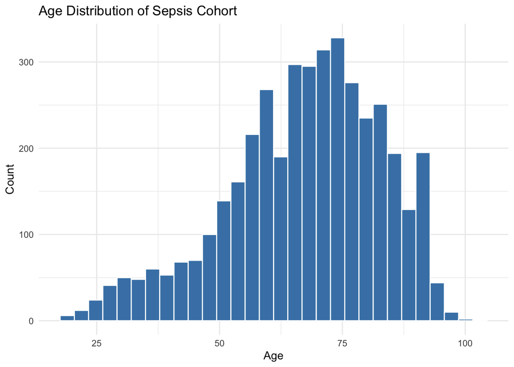

```r
# age distribution
ggplot(sepsis_cohort_final, aes(x = age_at_admit)) +
  geom_histogram(bins = 30, fill = "steelblue", color = "white") +
  theme_minimal() +
  labs(title = "Age Distribution of Sepsis Cohort", x = "Age", y = "Count")
```

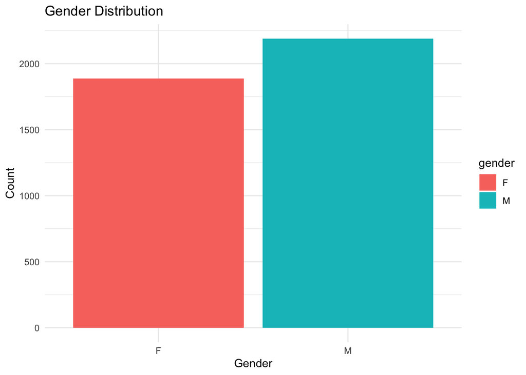

```r
# gender Breakdown
ggplot(sepsis_cohort_final, aes(x = gender, fill = gender)) +
  geom_bar() +
  theme_minimal() +
  labs(title = "Gender Distribution", x = "Gender", y = "Count")
```

```r
# lab IDs
lab_id_map <- list(
  lactate = c(50813, 52442, 53154),
  creatinine = c(50912, 52024, 52546),
  bilirubin = c(50885, 53089),
  wbc = c(51301, 51755, 51756),
  platelets = c(51265, 53189)
)

# filter for the first 24 hours of the ICU stay
labs_features_raw <- open_dataset("labevents_pq") %>%
  filter(hadm_id %in% sepsis_cohort_final$hadm_id) %>%
  filter(itemid %in% unlist(lab_id_map)) %>%
  collect() %>%
  inner_join(sepsis_cohort_final %>% select(hadm_id, intime), by = "hadm_id") %>%
  filter(charttime >= intime, charttime <= intime + hours(24)) %>%
  mutate(lab_name = case_when(
    itemid %in% lab_id_map$lactate ~ "max_lactate",
    itemid %in% lab_id_map$creatinine ~ "max_creatinine",
    itemid %in% lab_id_map$bilirubin ~ "max_bilirubin",
    itemid %in% lab_id_map$wbc ~ "max_wbc",
    itemid %in% lab_id_map$platelets ~ "min_platelets"
  )) %>%
  # biological sanitycCheck: remove extreme outliers/errors
  filter(
    !(lab_name == "max_lactate" & valuenum > 30),
    !(lab_name == "max_wbc" & valuenum > 200),
    !(lab_name == "min_platelets" & valuenum > 2000)
  )

# summarize to get the "worst" value per patient
labs_summarized <- labs_features_raw %>%
  group_by(hadm_id, lab_name) %>%
  summarize(
    val = if (all(is.na(valuenum))) {
      NA_real_  # If all values are NA, return a proper NA instead of -Inf
    } else if (str_detect(first(lab_name), "min")) {
      min(valuenum, na.rm = TRUE)
    } else {
      max(valuenum, na.rm = TRUE)
    },
    .groups = "drop"
  ) %>%
  pivot_wider(names_from = lab_name, values_from = val)

print("Labs Summarized Preview:")
```

```
[1] "Labs Summarized Preview:"
```

```r
labs_summarized %>% select(1:min(5, ncol(.))) %>% head()
```

```
# A tibble: 6 × 5
   hadm_id max_bilirubin max_creatinine max_lactate max_wbc
     <dbl>         <dbl>          <dbl>       <dbl>   <dbl>
1 20003014           1.1            0.8         1.8    16.7
2 20003427           3              2.6        16      42.4
3 20003491          NA              1.9        NA       6
4 20005024           0.3            0.7         2.3     6.5
5 20006154          NA              0.9         2.1    35.4
6 20009330           0.4            0.9         7.8     8.9
```

```r
# join labs to the master sepsis cohort
sepsis_cohort_final <- sepsis_cohort_final %>%
  left_join(labs_summarized, by = "hadm_id")

# check missingness before imputation
print("Missing counts BEFORE imputation:")
```

```
[1] "Missing counts BEFORE imputation:"
```

```r
print(colSums(is.na(sepsis_cohort_final %>% select(starts_with("max_"), starts_with("min_")))))
```

```
 max_bilirubin max_creatinine    max_lactate        max_wbc  min_platelets
           997             49            716             66             65
```

```r
# median imputation
sepsis_cohort_final <- sepsis_cohort_final %>%
  mutate(across(c(max_lactate, max_creatinine, max_bilirubin, max_wbc, min_platelets),
                ~ if_else(is.na(.), median(., na.rm = TRUE), .)))

# final verification
print("Missing counts AFTER imputation:")
```

```
[1] "Missing counts AFTER imputation:"
```

```r
print(colSums(is.na(sepsis_cohort_final %>% select(starts_with("max_"), starts_with("min_")))))
```

```
 max_bilirubin max_creatinine    max_lactate        max_wbc  min_platelets
             0              0              0              0              0
```

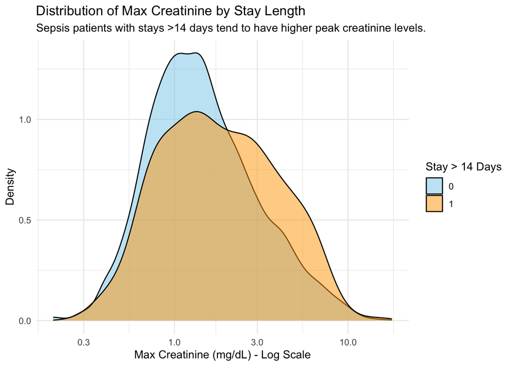

```r
ggplot(sepsis_cohort_final, aes(x = max_creatinine, fill = as.factor(prolonged_stay_14))) +
  geom_density(alpha = 0.5) +
  scale_x_log10() +
  theme_minimal() +
  scale_fill_manual(values = c("skyblue", "orange"), name = "Stay > 14 Days") +
  labs(
    title = "Distribution of Max Creatinine by Stay Length",
    subtitle = "Sepsis patients with stays >14 days tend to have higher peak creatinine levels.",
    x = "Max Creatinine (mg/dL) - Log Scale",
    y = "Density"
  )
```

```r
# IDs
vital_ids <- c(220045, 220210, 220181, 220052, 223761, 223762, 220179, 220050)
# join
vitals_cleaned <- open_dataset("chartevents_pq") %>%
  filter(stay_id %in% sepsis_cohort_final$stay_id) %>% # filter before collect!
  filter(itemid %in% vital_ids) %>%
  collect() %>%
  select(-any_of("hadm_id")) %>%
  mutate(stay_id = as.numeric(stay_id)) %>%
  inner_join(
    sepsis_cohort_final %>%
      mutate(stay_id = as.numeric(stay_id)) %>%
      select(stay_id, hadm_id, intime),
    by = "stay_id"
  ) %>%
  filter(charttime >= intime, charttime <= intime + hours(24))

# summarize: one median value per patient, per vital sign
vitals_summarized <- vitals_cleaned %>%
  mutate(vital_name = case_when(
    itemid == 220045 ~ "heart_rate",
    itemid == 220210 ~ "resp_rate",
    itemid %in% c(220181, 220052) ~ "mean_bp",
    itemid %in% c(220179, 220050) ~ "sys_bp",    # New Systolic BP
    itemid %in% c(223761, 223762) ~ "temp_f"
  )) %>%
  # convert Celsius to Fahrenheit if itemid is 223762
mutate(valuenum = if_else(itemid == 223762, (valuenum * 9/5) + 32, valuenum)) %>%

# biological sanity check: remove extreme outliers/errors
  filter(
    !(vital_name == "heart_rate" & (valuenum < 0 | valuenum > 300)),
    !(vital_name == "resp_rate" & (valuenum < 0 | valuenum > 100)),
    !(vital_name == "mean_bp" & (valuenum < 0 | valuenum > 300)),
    !(vital_name == "sys_bp" & (valuenum < 0 | valuenum > 300)),  # Added Sys BP
    !(vital_name == "temp_f" & (valuenum < 70 | valuenum > 115))
  ) %>%
  group_by(hadm_id, vital_name) %>%
  summarize(val = median(valuenum, na.rm = TRUE), .groups = "drop") %>%
  pivot_wider(names_from = vital_name, values_from = val)

# check result: should see hadm_id and the 4 vital columns
print("Structure of summarized vitals:")
```

```
[1] "Structure of summarized vitals:"
```

```r
head(vitals_summarized)
```

```
# A tibble: 6 × 6
   hadm_id heart_rate mean_bp resp_rate sys_bp temp_f
     <dbl>      <dbl>   <dbl>     <dbl>  <dbl>  <dbl>
1 20003014       77      89          19  120     98.9
2 20003427       90.5    88          26  134.    98.3
3 20003491       85      68          23   91     98.4
4 20005024       80.5    66.5        24   96.5   99.6
5 20006154       65      70          17  100     98.3
6 20009330       76.5    79          22   98     99.0
```

```r
v_cols <- c("heart_rate", "resp_rate", "mean_bp", "sys_bp", "temp_f")

# join the summarized vitals
sepsis_cohort_final <- sepsis_cohort_final %>%
  select(-any_of(v_cols)) %>%  # wipe out old versions if they exist
  left_join(vitals_summarized, by = "hadm_id")

# print missingness stats
missing_report <- sepsis_cohort_final %>%
  summarise(across(any_of(v_cols),
                   list(
                     count = ~sum(is.na(.)),
                     percent = ~round(sum(is.na(.)) / n() * 100, 2)
                   )))

print("--- Vital Signs Missingness Report (Pre-Imputation) ---")
```

```
[1] "--- Vital Signs Missingness Report (Pre-Imputation) ---"
```

```r
print(missing_report)
```

```
# A tibble: 1 × 10
  heart_rate_count heart_rate_percent resp_rate_count resp_rate_percent
             <int>              <dbl>           <int>             <dbl>
1                1               0.02               2              0.05
# ℹ 6 more variables: mean_bp_count <int>, mean_bp_percent <dbl>,
#   sys_bp_count <int>, sys_bp_percent <dbl>, temp_f_count <int>,
#   temp_f_percent <dbl>
```

```r
# median imputation (we have low missing % values, teammate confirmed with TAs)
sepsis_cohort_final <- sepsis_cohort_final %>%
  mutate(across(any_of(v_cols),
                ~ if_else(is.na(.), median(., na.rm = TRUE), .)))

# final verification - should be 0 now
print("--- Final Missing Count Check (Vitals) ---")
```

```
[1] "--- Final Missing Count Check (Vitals) ---"
```

```r
print(colSums(is.na(sepsis_cohort_final %>% select(any_of(v_cols)))))
```

```
heart_rate  resp_rate    mean_bp     sys_bp     temp_f
         0          0          0          0          0
```

```r
# grab diagnoses and filter for our sepsis crew
diagnoses <- read_csv("~/mimic/hosp/diagnoses_icd.csv.gz") %>%
  filter(hadm_id %in% sepsis_cohort_final$hadm_id)

# flag the comorbidities using regex (checking for both ICD9/10)
comorbidities <- diagnoses %>%
  group_by(hadm_id) %>%
  summarize(
    hypertension = max(if_else(str_detect(icd_code, "^I1[0-5]|^40[1-5]"), 1, 0)),
    diabetes = max(if_else(str_detect(icd_code, "^E0[8-9]|^E1[0-3]|^250"), 1, 0)),
    ckd = max(if_else(str_detect(icd_code, "^N18|^585"), 1, 0)),
    cvd = max(if_else(str_detect(icd_code, "^I2[0-5]|^I50|^41[0-4]|^428"), 1, 0)),
    liver_disease = max(if_else(str_detect(icd_code, "^B18|^K7[0-6]|^571"), 1, 0)),
    immunosuppression = max(if_else(str_detect(icd_code, "^D8[0-9]|^279|^V581|^Z511"), 1, 0))
  ) %>%
  ungroup()

# join to the master table and clean up
# use sepsis_cohort_final here so we keep our vitals and labs!
sepsis_cohort_final <- sepsis_cohort_final %>%
  select(-any_of(colnames(comorbidities)[-1])) %>% # avoid duplicate col drama
  left_join(comorbidities, by = "hadm_id") %>%
  # if no code code, assume they don't have the condition (set to 0)
  mutate(across(c(hypertension, diabetes, ckd, cvd, liver_disease, immunosuppression),
                ~ if_else(is.na(.), 0, .))) %>%
  # make them factors so the Random Forest treats them as categories, not numbers
  mutate(across(c(hypertension, diabetes, ckd, cvd, liver_disease, immunosuppression), as.factor))

# distribution
summary(sepsis_cohort_final %>% select(hypertension, diabetes, ckd))
```

```
 hypertension diabetes ckd
 0:1464       0:2547   0:2946
 1:2613       1:1530   1:1131
```

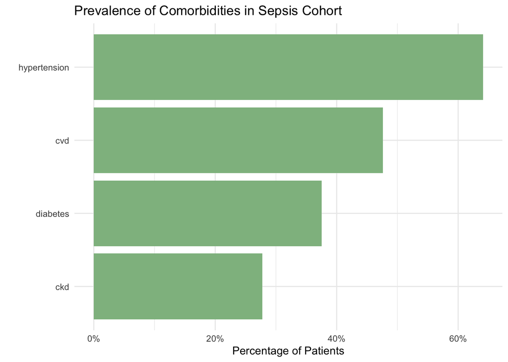

```r
# prevalence of comorbidities
comorb_plot <- sepsis_cohort_final %>%
  select(hypertension, diabetes, ckd, cvd) %>%
  mutate(across(everything(), ~ as.numeric(as.character(.)))) %>%
  summarise(across(everything(), mean)) %>%
  pivot_longer(everything(), names_to = "Condition", values_to = "Prevalence")

ggplot(comorb_plot, aes(x = reorder(Condition, Prevalence), y = Prevalence)) +
  geom_bar(stat = "identity", fill = "darkseagreen") +
  scale_y_continuous(labels = scales::percent) +
  coord_flip() +
  theme_minimal() +
  labs(title = "Prevalence of Comorbidities in Sepsis Cohort", x = "", y = "Percentage of Patients")
```

```r
# load prescriptions and filter for our cohort
# using prescriptions for vasopressors is good, though some are in inputevents
prescriptions_raw <- read_csv("~/mimic/hosp/prescriptions.csv.gz") %>%
  filter(hadm_id %in% sepsis_cohort_final$hadm_id)

# flag vasopressors in the first 24 hours
vaso_flags <- prescriptions_raw %>%
  left_join(sepsis_cohort_final %>% select(hadm_id, intime), by = "hadm_id") %>%
  # filter: was the drug started within 24 hours of ICU admission?
  filter(starttime >= intime & starttime <= (intime + hours(24))) %>%
  mutate(drug = tolower(drug)) %>%
  group_by(hadm_id) %>%
  summarize(
    vasopressors = max(if_else(str_detect(drug, "norepinephrine|epinephrine|phenylephrine|vasopressin|dopamine"), 1, 0)),
    .groups = "drop"
  )

# join back to the master table
sepsis_cohort_final <- sepsis_cohort_final %>%
  # remove old version if it exists
  select(-any_of("vasopressors")) %>%
  left_join(vaso_flags, by = "hadm_id") %>%
  # if a patient wasn't in the vaso_flags list, they didn't get pressors (set to 0)
  mutate(vasopressors = if_else(is.na(vasopressors), 0, as.numeric(vasopressors))) %>%
  # make it a factor for the model
  mutate(vasopressors = as.factor(vasopressors))

# final Count Check
print("Distribution of Vasopressor use in first 24h:")
```

```
[1] "Distribution of Vasopressor use in first 24h:"
```

```r
table(sepsis_cohort_final$vasopressors)
```

```
   0    1
1608 2469
```

```r
# check for any remaining NAs in your potential predictors
colSums(is.na(sepsis_cohort_final %>%
                select(hospital_expire_flag, age_at_admit, gender, race_group,
                       starts_with("max_"), starts_with("min_"),
                       heart_rate, mean_bp, sys_bp, resp_rate, temp_f,
                       hypertension, diabetes, ckd, cvd, vasopressors)))
```

```
hospital_expire_flag         age_at_admit               gender
                   0                    0                    0
          race_group        max_bilirubin       max_creatinine
                   0                    0                    0
         max_lactate              max_wbc        min_platelets
                   0                    0                    0
          heart_rate              mean_bp               sys_bp
                   0                    0                    0
           resp_rate               temp_f         hypertension
                   0                    0                    0
            diabetes                  ckd                  cvd
                   0                    0                    0
        vasopressors
                   0
```

```r
# checking for weird outliers or extreme values
sepsis_cohort_final %>%
  select(age_at_admit, heart_rate, resp_rate, mean_bp, sys_bp, temp_f,
         max_lactate, max_creatinine, max_bilirubin) %>%
  summary()
```

```
  age_at_admit     heart_rate       resp_rate        mean_bp
 Min.   : 19.0   Min.   : 39.50   Min.   : 0.00   Min.   : 38.50
 1st Qu.: 58.0   1st Qu.: 76.50   1st Qu.:17.50   1st Qu.: 69.00
 Median : 69.0   Median : 88.50   Median :20.00   Median : 73.50
 Mean   : 67.3   Mean   : 89.53   Mean   :20.96   Mean   : 75.14
 3rd Qu.: 79.0   3rd Qu.:101.00   3rd Qu.:24.00   3rd Qu.: 80.00
 Max.   :103.0   Max.   :166.00   Max.   :42.00   Max.   :142.00
     sys_bp          temp_f        max_lactate     max_creatinine
 Min.   : 55.0   Min.   : 91.04   Min.   : 0.500   Min.   : 0.20
 1st Qu.:101.0   1st Qu.: 98.00   1st Qu.: 1.600   1st Qu.: 0.90
 Median :108.0   Median : 98.40   Median : 2.100   Median : 1.40
 Mean   :110.5   Mean   : 98.52   Mean   : 2.809   Mean   : 1.95
 3rd Qu.:117.5   3rd Qu.: 98.90   3rd Qu.: 3.000   3rd Qu.: 2.30
 Max.   :174.5   Max.   :104.00   Max.   :28.000   Max.   :17.90
 max_bilirubin
 Min.   : 0.100
 1st Qu.: 0.500
 Median : 0.800
 Mean   : 1.863
 3rd Qu.: 1.300
 Max.   :53.100
```

```r
sepsis_cohort_final <- sepsis_cohort_final %>%
  mutate(
    # fix 0 respiratory rates using the median (if it were a prolonged 0 average then the patient would be dead...)
    resp_rate = if_else(resp_rate <= 0, median(resp_rate[resp_rate > 0], na.rm = TRUE), resp_rate),
    # fix the 0 mean_bp using the median
    mean_bp = if_else(mean_bp <= 0, median(mean_bp[mean_bp > 0], na.rm = TRUE), mean_bp),
    # ensure our stay flag is a factor for the model
    prolonged_stay_14 = as.factor(prolonged_stay_14)
  )

# verify 0 is gone
summary(sepsis_cohort_final$resp_rate)
```

```
   Min. 1st Qu.  Median    Mean 3rd Qu.    Max.
   6.00   17.50   20.00   20.96   24.00   42.00
```

```r
# list all column names to make sure everything joined correctly
colnames(sepsis_cohort_final)
```

```
 [1] "subject_id"           "hadm_id"              "stay_id"
 [4] "first_careunit"       "last_careunit"        "intime"
 [7] "outtime"              "los"                  "gender"
[10] "anchor_age"           "anchor_year"          "anchor_year_group"
[13] "dod"                  "race"                 "insurance"
[16] "hospital_expire_flag" "age_at_admit"         "prolonged_stay_14"
[19] "race_group"           "max_bilirubin"        "max_creatinine"
[22] "max_lactate"          "max_wbc"              "min_platelets"
[25] "heart_rate"           "mean_bp"              "resp_rate"
[28] "sys_bp"               "temp_f"               "hypertension"
[31] "diabetes"             "ckd"                  "cvd"
[34] "liver_disease"        "immunosuppression"    "vasopressors"
```

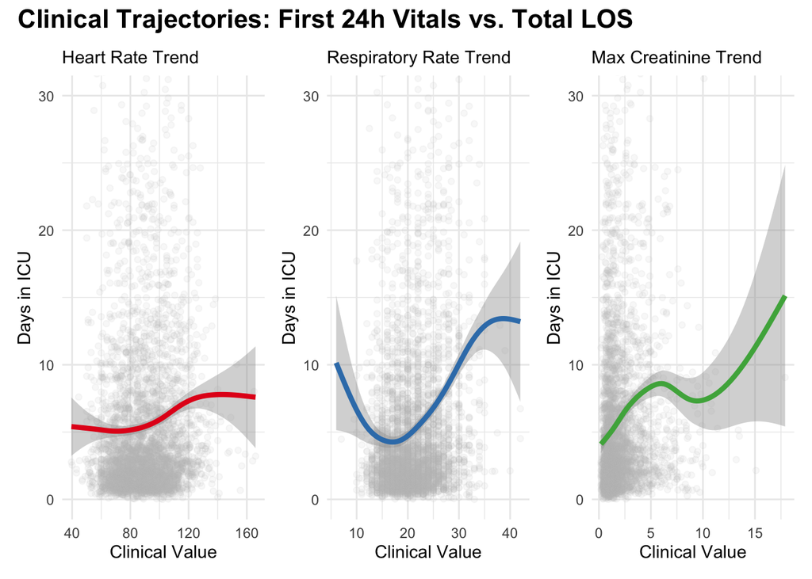

```r
library(tidyverse)
library(patchwork) # To combine the 3 plots easily

# Update your make_traj function slightly:
make_traj <- function(var_name, title_lab, color_hex) {
  ggplot(sepsis_cohort_final, aes(x = .data[[var_name]], y = los)) +
    geom_point(alpha = 0.1, color = "grey") +
    geom_smooth(method = "gam", color = color_hex, size = 1.5) +
    coord_cartesian(ylim = c(0, 30)) + # <--- THIS IS THE MAGIC LINE
    theme_minimal() +
    labs(subtitle = title_lab, x = "Clinical Value", y = "Days in ICU")
}

# 2. Generate the 3 plots using your actual variables
p1 <- make_traj("heart_rate", "Heart Rate Trend", "#e41a1c")
p2 <- make_traj("resp_rate", "Respiratory Rate Trend", "#377eb8")
p3 <- make_traj("max_creatinine", "Max Creatinine Trend", "#4daf4a")

# 3. Combine them into one "Trajectory" Visual
trajectory_plot <- (p1 | p2 | p3) +
  plot_annotation(title = "Clinical Trajectories: First 24h Vitals vs. Total LOS",
                  theme = theme(plot.title = element_text(size = 16, face = "bold")))


trajectory_plot
```

```r
#saveRDS(trajectory_plot, "trajectory_plot.rds")
```

4.3 Analytical Approach/Modeling

As established in our data extraction phase, the primary clinical objective is to identify patients likely to require heavy ICU resource utilization.

- **Index Time:** The “Time Zero” for our model is the moment of ICU admission.
- **Prediction Window:** We utilized a **24-hour observation window**. Only data generated within the first day of stay was used for prediction to ensure early clinical utility.
- **Outcome Definition:** A binary classification of **Prolonged ICU Stay**, defined as a total length of stay (LOS) **exceeding 14 days**

To find the optimal balance between clinical interpretability and predictive power, we implemented and compared three distinct machine learning architectures:

1. **Lasso Regression (Regularized Logistic Regression):** This served as our primary interpretable model. By using an L1 penalty, the model performs automatic feature selection, which is vital for clinicians to understand which of the 19 features (e.g., Max Lactate) are driving the risk score.
2. **Random Forest:** A non-linear ensemble method used to account for complex interactions between physiological variables (e.g., the interaction between low Blood Pressure and high Heart Rate).
3. **XGBoost (Extreme Gradient Boosting):** A high-performance boosting algorithm used to establish the “predictive ceiling” of our 19-feature dataset.

All analyses were conducted using the **R Programming Language (v4.3+)**. The following ecosystem of packages was instrumental to the project:

- **Data Pipeline:** We utilized the **tidyverse** suite, including **dplyr**, **tidyr**, **stringr**, **ggplot2**, **readr**, and **lubridate**, to perform the core data manipulation, string cleaning, and temporal processing of ICU admission dates. For high-performance data handling, **data.table** and **R.utils** were used to manage large file structures, while **arrow** provided a memory-efficient way to interface with Parquet-formatted data.The **gtsummary** package was used to generate clinical-grade baseline characteristics tables, and **pROC** was employed to calculate and visualize the Area Under the Receiver Operating Characteristic curves for our models. We monitored computational efficiency and memory footprints using **memuse** and **pryr**, which is critical when processing high-resolution MIMIC-IV datasets.

  For the machine learning phase, **caret** served as the primary workflow wrapper to handle training and cross-validation, while **glmnet** and **randomForest** provided the specific engines for our Lasso regression and ensemble-based models.
- **Communication:** `Quarto` was used for the final report generation, and `Shiny` was used for the interactive clinical deliverable.

```r
# predictor list
final_predictors <- c(
  "age_at_admit", "gender", "race_group", "insurance",
  "max_lactate", "max_creatinine", "max_bilirubin", "max_wbc", "min_platelets",
  "heart_rate", "mean_bp", "sys_bp", "resp_rate", "temp_f",
  "hypertension", "diabetes", "ckd", "cvd", "vasopressors"
)

print(paste("Number of Predictors:", length(final_predictors)))
```

```
[1] "Number of Predictors: 19"
```

4.4 Model Evaluation